# Análisis de proximidades

José Félix Rojas Cabeza

6/5/2020

# Ejercicio 1: Similitudes entre siete animales

La matriz adjunta indica las similitudes entre siete animales según un experto:

Similitudes entre 7 animales

|  | A | B | C | D | E | F | G |
| --- | --- | --- | --- | --- | --- | --- | --- |
| A | 0 | 7 | 5 | 9 | 5 | 7 | 9 |
| B | 7 | 0 | 4 | 6 | 4 | 6 | 7 |
| C | 5 | 4 | 0 | 3 | 4 | 5 | 6 |
| D | 9 | 6 | 3 | 0 | 3 | 2 | 2 |
| E | 5 | 4 | 4 | 3 | 0 | 5 | 4 |
| F | 7 | 6 | 5 | 2 | 5 | 0 | 4 |
| G | 9 | 7 | 6 | 2 | 4 | 4 | 0 |

1. construir la matriz $B=-\frac{1}{2}HD^{(2)}$ donde $D^{(2)}$ es la matriz de distancias al cuadrado y $H$ es la matriz de centrado, y calcular sus valores propios. Observar si la matríz de distancias es euclídea:

```r
> n <- 7
> I <- diag(rep(1, n))
> H <- I - 1/n*(rep(1, n) %*% t(rep(1, n)))
> B <- -(1/2)*(H %*% A_1^2 %*% H )
>
> colnames(B) <- c("A", "B", "C", "D", "E", "F", "G")
> rownames(B) <- c("A", "B", "C", "D", "E", "F", "G")
>
> # Matriz B
> round(B,3)
```

```
        A      B      C       D      E      F       G
A  31.571 -0.643  6.000 -20.857  4.571 -4.000 -16.643
B  -0.643 16.143  2.786  -6.071  1.357 -5.214  -8.357
C   6.000  2.786  5.429   2.071 -4.000 -5.071  -7.214
D -20.857 -6.071  2.071   7.714  0.643  6.571   9.929
E   4.571  1.357 -4.000   0.643  2.571 -6.500   1.357
F  -4.000 -5.214 -5.071   6.571 -6.500  9.429   4.786
G -16.643 -8.357 -7.214   9.929  1.357  4.786  16.143
```

```r
> # Autovalores
> eigen(B)$values
```

```
[1]  5.791850e+01  2.142208e+01  1.219826e+01  8.714724e+00  4.137911e-01
[6] -1.243450e-14 -1.166735e+01
```

```r
> # Euclidea?
> if(!(require(ade4))) install.packages("ade4")
> library(ade4)
> is.euclid(as.dist(A_1))
```

```
[1] FALSE
```

La función `is.euclid()` indica que A_1 no es euclídea, también se puede deducir, observando que algunos autovalores son negativos.

2. Obtener la representación con las dos primeras coordenadas principales e indicar el grado de bondad de esta representación.

Se puede hacer a partir de la descomposición de la matriz B o con la función `cmdscale(dist, eig=T)`.

```r
> # Multidimensional Scaling
> M <- cmdscale(as.dist(A_1), eig = TRUE)
>
> M
```

```
$points
        [,1]        [,2]
A  5.3653128  2.10386005
B  1.3884389 -3.58622610
C  1.1638928 -0.81833285
D -3.2507539 -0.24452185
E  0.4520411 -0.02609855
F -1.5654748  1.50797637
G -3.5534569  1.06334294

$eig
[1]  5.791850e+01  2.142208e+01  1.219826e+01  8.714724e+00  4.137911e-01
[6] -5.329071e-15 -1.166735e+01

$x
NULL

$ac
[1] 0

$GOF
[1] 0.7062874 0.7881461
```

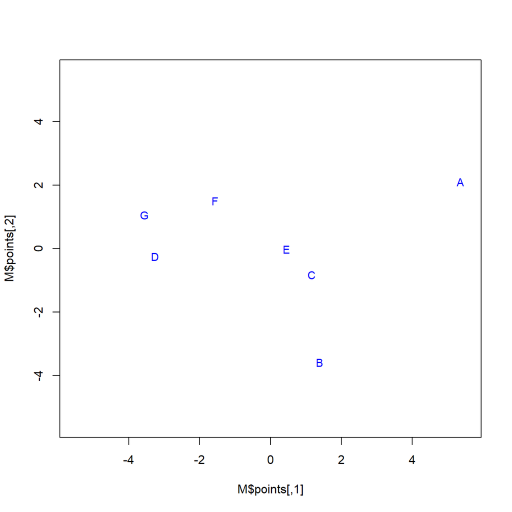

```r
> # Plot
> plot(M$points, type = "n", xlim = c(-5.5,5.5), ylim = c(-5.5,5.5) )
> text(M$points[,1], M$points[,2], labels = rownames(A_1), cex= .9, col = "blue")
```

# Ejercicio 4: Variables binarias

Si las variables observadas sobre un conjunto de individuos son del tipo binario, es necesario disponer de una matriz de distancias basadas en los coeficientes de similaridad que se obtienen de las tablas del tipo

|  | 1 | 0 |
| --- | --- | --- |
| 1 | A | B |
| 0 | C | D |

donde a es el número de variables con respuesta 1 en ambos individuos, d es el número de variables con respuesta 0 en ambos individuos, etc.

Entre los muchos coeficientes de similaridad destacan dos:

$$Sokal\space y\space Michener:\space S_{ij}=\frac{a+d}{p} \quad Jaccard: S_{ij}=\frac{a}{p-d}$$

donde $p=a+b+c+d$ es el número de variables binarias observadas.

El coeficiente de Sokal y Michener se utiliza con variables binarias simétricas, es decir, aquellas en las que los valores 1 y 0 son intercambiables. Uno no es más importante que el otro, como el sexo. El coeficiente de Jaccard, en cambio, se utiliza con variables binarias asimétricas, es decir, aquellas en las que la presencia de la característica (el 1) es importante.

Aplicando uno de estos coeficientes a un conjunto de individuos se obtiene una matriz de similaridades $(s_{ij})$ que se puede transformar en una distancia

$$d^2_{ij}= s_{ii}+s_{jj}-2s_{ij} =2(1-s_{ij})$$

Dada la siguiente matriz de datos:

|  | X1 | X2 | X3 | X4 | X5 | X6 |
| --- | --- | --- | --- | --- | --- | --- |
| A | 1 | 1 | 0 | 0 | 1 | 1 |
| B | 1 | 1 | 1 | 0 | 0 | 1 |
| C | 1 | 0 | 0 | 1 | 0 | 1 |
| D | 0 | 0 | 0 | 0 | 1 | 0 |

con las observaciones de 6 variables binarias sobre 4 individuos,

1. Calcular los coeficientes de Sokal y Michener para cada par de individuos y obtener la matriz de distancias asociada.

```r
> sim_SM <- function(x,y) {
+   if (length(x) != length(y)) {
+     stop ("Los vectores deben tener la misma longitud")}
+   else {
+     a <- sum(x==1 & y==1)
+     d <- sum(x==0 & y==0)
+     (a+d)/length(x)
+   }
+ }
>
> sim_bin <- function(X, sim) {
+   n <- nrow(X)
+   S <- matrix(0, nrow=n,ncol=n)
+   for (i in 1:(n-1))
+     for (j in (i+1):n)
+       S[i,j] <- sim(X[i,], X[j,])
+       S <- S + diag(1,n) + t(S)
+       rownames(S) <- colnames(S) <- rownames(X)
+       as.dist(2*(1-S))
+ }
>
> sim_bin(B_4, sim_SM)
```

```
          A         B         C
B 0.6666667
C 1.0000000 1.0000000
D 1.0000000 1.6666667 1.3333333
```

2. Lo mismo que en el apartado anterior pero con el coeficiente de Jaccard:

```r
> sim_J <- function(x,y) {
+   if (length(x) != length(y)) {
+     stop ("Los vectores deben tener la misma longitud")}
+   else {
+     a <- sum(x==1 & y==1)
+     d <- sum(x==0 & y==0)
+     a/(length(x)-d)
+   }
+ }
>
> sim_bin(B_4, sim_J)
```

```
    A   B   C
B 0.8
C 1.2 1.2
D 1.5 2.0 2.0
```

# Ejercicio 5: `Cluster::flower`

En muchos análisis multivariantes se dispone de un conjunto de variables mixto, es decir, unas variables son del tipo cuantitativo y otras cualitativo (nominales, ordinales o incluso binarias). En estos casos es necesario disponer de una distancia como la de Gower que tiene en cuenta el tipo de variable.

El cuadrado de la distancia de Gower entre dos filas de datos se define como $d^2_{ij} = 1 − s_{ij}$, donde $s_{ij}$ es el coeficiente de similaridad

$$s_{ij}=\frac{\sum^{p_1}_{h=1}(1-|x_{ih}-x_{jh}|/G_h)+a+\alpha}{p_1+(p_2-d)+p_3}$$

$p_1$ es el número de variables cuantitativas, $p_2$ es el número de variables binarias, $p_3$ el número de variables cualitativas (no binarias), a el número de coincidencias (1, 1) en las variables binarias, d el número de coincidencias (0, 0) en las variables binarias, $\alpha$ el número de coincidencias en las variables cualitativas (no binarias) y $G_h$ es el rango (o recorrido) de la $h$-ésima variable cuantitativa

1. Calcular la distancia de Gower entre los datos de 18 tipos de flores de la base de datos flower del paquete cluster de R. Probar la función `daisy()` del paquete cluster.

```r
> if(!(require(cluster))) install.packages("cluster")
> library(cluster)
> A_5 <- cluster::flower
> colnames(A_5) <- c("winters","shadow","tubers","color","soil","pref","height","distance")
> str(A_5)
```

```
'data.frame':   18 obs. of  8 variables:
 $ winters : Factor w/ 2 levels "0","1": 1 2 1 1 1 1 1 1 2 2 ...
 $ shadow  : Factor w/ 2 levels "0","1": 2 1 2 1 2 2 1 1 2 2 ...
 $ tubers  : Factor w/ 2 levels "0","1": 2 1 1 2 1 1 1 2 1 1 ...
 $ color   : Factor w/ 5 levels "1","2","3","4",..: 4 2 3 4 5 4 4 2 3 5 ...
 $ soil    : Ord.factor w/ 3 levels "1"<"2"<"3": 3 1 3 2 2 3 3 2 1 2 ...
 $ pref    : Ord.factor w/ 18 levels "1"<"2"<"3"<"4"<..: 15 3 1 16 2 12 13 7 4 14 ...
 $ height  : num  25 150 150 125 20 50 40 100 25 100 ...
 $ distance: num  15 50 50 50 15 40 20 15 15 60 ...
```

```r
> # Gower Distance
> G_dist <- daisy(A_5, metric = "gower", type=list(symm=c(1,2), asymm=3))
>
> attr(G_dist,"Types")
```

```
[1] "S" "S" "A" "N" "O" "O" "I" "I"
```

2. Realizar un escalado multidimensional con esta distancia y representar las flores en un gráfico de dispersión de dos dimensiones.

```r
> # Multidimensional scaling
> M_5 <- cmdscale(G_dist, eig = T)
> M_5
```

```
$points
             [,1]         [,2]
 [1,]  0.29679786 -0.267818251
 [2,] -0.37498350  0.185603174
 [3,]  0.09175369 -0.014312588
 [4,] -0.18695632 -0.351656935
 [5,]  0.32275116  0.046753019
 [6,]  0.16540081 -0.185220673
 [7,]  0.02095674 -0.305706225
 [8,] -0.04058749 -0.172534548
 [9,]  0.16345140  0.334351964
[10,] -0.08006258  0.220997949
[11,]  0.25101547  0.102385809
[12,]  0.07838220  0.134277648
[13,]  0.16398347  0.269159304
[14,]  0.04093219  0.006265813
[15,] -0.09951482  0.132503360
[16,] -0.41848238 -0.052096511
[17,] -0.43414959  0.049266822
[18,]  0.03931167 -0.132219131

$eig
 [1]  9.115922e-01  6.915706e-01  5.317533e-01  3.574191e-01  2.190966e-01
 [6]  1.089910e-01  5.540941e-02  4.734512e-02  2.111761e-02 -5.551115e-17
[11] -2.387905e-03 -1.890756e-02 -2.356828e-02 -4.479860e-02 -6.770476e-02
[16] -1.065829e-01 -1.313834e-01 -1.566752e-01

$x
NULL

$ac
[1] 0

$GOF
[1] 0.4585308 0.5444980
```

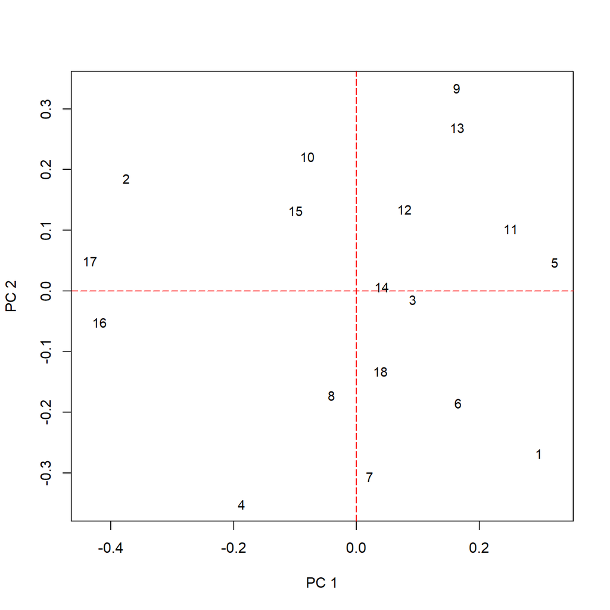

```r
> plot(M_5$points, type = "n", xlab="PC 1", ylab="PC 2")
> abline(h=0,v=0,lty=5,col="red", lwd=1)
> text(M_5$points[,1], M_5$points[,2], labels = 1:18, cex=0.9)
```

```r
> # bondad de ajuste
> evv <- cmdscale(G_dist, k=17, eig = T)$eig
> sum(evv[1:2]/sum(evv[evv>0]))
```

```
[1] 0.544498
```

# Ejercicio 6: `Chap5skulls.dat`

Consideremos los datos sobre cráneos de varones egipcios de cinco épocas históricas que se pueden bajar desde la [página del libro de Everitt](https://www.york.ac.uk/depts/maths/data/everitt/welcome.htm) (2005). Los podremos cargar directamente en R con la siguientes instrucciones:

```
skulls <- source("/(path)/chap5skulls.dat")$value
str(skulls)
attach(skulls)
```

Donde el path debe ser la dirección a la carpeta donde hemos dejado el archivo una vez descomprimido. Así tendremos la base de datos skulls con cinco variables. La primera variable es el factor EPOCH y las otras cuatro son las medidas biométricas estudiadas del cráneo.

```
'data.frame':   150 obs. of  5 variables:
 $ EPOCH: Factor w/ 5 levels "c4000BC","c3300BC",..: 1 1 1 1 1 1 1 1 1 1 ...
 $ MB   : num  131 125 131 119 136 138 139 125 131 134 ...
 $ BH   : num  138 131 132 132 143 137 130 136 134 134 ...
 $ BL   : num  89 92 99 96 100 89 108 93 102 99 ...
 $ NH   : num  49 48 50 44 54 56 48 48 51 51 ...
```

1. En primer lugar podemos realizar un MANOVA para contrastar la diferencia de medias entre los niveles del factor o poblaciones. No entraremos aquí en la comprobación de las hipótesis de normalidad y de igualdad de las matrices de covarianzas.

```r
> manova <- manova(cbind(MB, BH, BL, NH) ~ EPOCH, data=skulls)
> summary(manova, test="Wilks")
```

```
           Df   Wilks approx F num Df den Df   Pr(>F)
EPOCH       4 0.66359   3.9009     16 434.45 7.01e-07 ***
Residuals 145
---
Signif. codes:  0 '***' 0.001 '**' 0.01 '*' 0.05 '.' 0.1 ' ' 1
```

El p valor indica que hay diferencias entre las medias de las poblaciones.

2. (∗∗) Comprobaremos que el test anterior rechaza la igualdad de medias y, por lo tanto, justificaun análisis canónico de poblaciones.

Utilizar la función candisc() del paquete candisc o consultar

http://erre-que-erre-paco.blogspot.com/2010/03/analisis-canonico-de-poblaciones.html

Al comprobarse la diferencia de medias, tiene sentido hacer un análisis canónico de poblaciones:

```r
> # Matriz centrada de medias
> attach(skulls)
> nT <- nrow(skulls)
> p <- ncol(skulls)-1
> g <- nlevels(EPOCH)
> (n_i <- tapply(EPOCH, EPOCH, length))
```

```
c4000BC c3300BC c1850BC  c200BC  cAD150
     30      30      30      30      30
```

```r
> # vector de medias global
> (g_mean <- apply(skulls[,2:5], 2, mean))
```

```
       MB        BH        BL        NH
133.97333 132.54667  96.46000  50.93333
```

```r
> # Medias grupales
> means <- aggregate(skulls[,2:5], by=list(EPOCH), mean)
> means <- as.matrix(means[,2:5])
> rownames(means) <- levels(EPOCH)
> round(means,3)
```

```
             MB      BH     BL     NH
c4000BC 131.367 133.600 99.167 50.533
c3300BC 132.367 132.700 99.067 50.233
c1850BC 134.467 133.800 96.033 50.567
c200BC  135.500 132.300 94.533 51.967
cAD150  136.167 130.333 93.500 51.367
```

```r
> # Matriz centrada de medias
> X <- means - matrix(g_mean, nrow = g, ncol = p, byrow = TRUE)
> round(X,3)
```

```
            MB     BH     BL     NH
c4000BC -2.607  1.053  2.707 -0.400
c3300BC -1.607  0.153  2.607 -0.700
c1850BC  0.493  1.253 -0.427 -0.367
c200BC   1.527 -0.247 -1.927  1.033
cAD150   2.193 -2.213 -2.960  0.433
```

```r
> # Matriz de covarianzas de grupo (denominador n-1)
> (S_list <- by(skulls[,2:5], skulls$EPOCH, FUN=cov))
```

```
skulls$EPOCH: c4000BC
          MB         BH         BL         NH
MB 26.309195  4.1517241  0.4540230  7.2459770
BH  4.151724 19.9724138 -0.7931034  0.3931034
BL  0.454023 -0.7931034 34.6264368 -1.9195402
NH  7.245977  0.3931034 -1.9195402  7.6367816
------------------------------------------------------------
skulls$EPOCH: c3300BC
          MB        BH         BL        NH
MB 23.136782  1.010345  4.7678161 1.8425287
BH  1.010345 21.596552  3.3655172 5.6241379
BL  4.767816  3.365517 18.8919540 0.1908046
NH  1.842529  5.624138  0.1908046 8.7367816
------------------------------------------------------------
skulls$EPOCH: c1850BC
           MB          BH         BL          NH
MB 12.1195402  0.78620690 -0.7747126  0.89885057
BH  0.7862069 24.78620690  3.5931034 -0.08965517
BL -0.7747126  3.59310345 20.7229885  1.67011494
NH  0.8988506 -0.08965517  1.6701149 12.59885057
------------------------------------------------------------
skulls$EPOCH: c200BC
          MB        BH        BL       NH
MB 15.362069 -5.534483 -2.172414 2.051724
BH -5.534483 26.355172  8.110345 6.148276
BL -2.172414  8.110345 21.085057 5.328736
NH  2.051724  6.148276  5.328736 7.964368
------------------------------------------------------------
skulls$EPOCH: cAD150
           MB         BH         BL         NH
MB 28.6264368 -0.2298851 -1.8793103 -1.9942529
BH -0.2298851 24.7126437 11.7241379  2.1494253
BL -1.8793103 11.7241379 25.5689655  0.3965517
NH -1.9942529  2.1494253  0.3965517 13.8264368
```

```r
> # Matriz de covarianzas de grupo (W)
> S <- matrix(0,nrow=4,ncol=4)
> for(i in 1:g){ S <- S + n_i[i]*S_list[[i]] }
> S <- S/nT
> round(S,3)
```

```
       MB     BH     BL     NH
MB 21.111  0.037  0.079  2.009
BH  0.037 23.485  5.200  2.845
BL  0.079  5.200 24.179  1.133
NH  2.009  2.845  1.133 10.153
```

```r
> # Cholesky
> A <- crossprod(X)
> T_ <- chol(S)
> T_inv <- solve(T_)
> (ev <- eigen( t(T_inv) %*% A %*% T_inv ) )
```

```
eigen() decomposition
$values
[1] 2.054627647 0.188494673 0.075904888 0.009765007

$vectors
           [,1]       [,2]       [,3]      [,4]
[1,]  0.6154648  0.1447008 -0.2974889 0.7153776
[2,] -0.2865995  0.8997428  0.2759714 0.1793414
[3,] -0.6878362 -0.3348596 -0.0402855 0.6427500
[4,]  0.2567980 -0.2395695  0.9130812 0.2072295
```

```r
> evv <- ev$values
> (pct <- round(evv/sum(evv)*100, 2))
```

```
[1] 88.23  8.09  3.26  0.42
```

Vectores propios $T'^{-1}AT^{-1}TV$:

```r
> TV <- ev$vectors
```

Vectores propios $VT^{-1}(TV)$:

```r
> V2 <- T_inv %*% TV
> round(V2, 3)
```

```
     [,1]   [,2]   [,3]  [,4]
MB  0.127  0.039 -0.093 0.149
BH -0.037  0.210  0.025 0.000
BL -0.145 -0.068 -0.015 0.133
NH  0.083 -0.077  0.295 0.067
```

Ortogonales:

```r
> t(V2) %*% A %*% V2
```

```
              [,1]          [,2]          [,3]         [,4]
[1,]  2.054628e+00 -2.220446e-16 -1.665335e-16 2.359224e-16
[2,] -3.079134e-16  1.884947e-01 -2.012279e-16 1.769418e-16
[3,] -1.040834e-17 -1.526557e-16  7.590489e-02 1.353084e-16
[4,] -2.417771e-17  2.065405e-16  1.474515e-16 9.765007e-03
```

Ortonormales:

```r
> t(V2) %*% S %*% V2
```

```
              [,1]         [,2]          [,3]          [,4]
[1,]  1.000000e+00 1.387779e-17  2.775558e-17 -9.020562e-17
[2,] -3.989864e-17 1.000000e+00  0.000000e+00  1.162265e-16
[3,] -2.775558e-17 2.775558e-17  1.000000e+00  2.775558e-17
[4,] -8.326673e-17 9.714451e-17 -5.551115e-17  1.000000e+00
```

```r
> #coordenadas canónicas para medias centradas
> round(X %*% V2, 3)
```

```
          [,1]   [,2]   [,3]   [,4]
c4000BC -0.795 -0.033  0.110 -0.057
c3300BC -0.645 -0.153 -0.092  0.059
c1850BC  0.048  0.340 -0.117 -0.008
c200BC   0.568  0.059  0.185  0.041
cAD150   0.825 -0.212 -0.087 -0.036
```

```r
> #coordenadas canónicas para medias no centradas
> Y <- means %*% V2
> round(Y, 3)
```

```
         [,1]   [,2]  [,3]   [,4]
c4000BC 1.489 22.497 4.520 36.015
c3300BC 1.638 22.377 4.318 36.131
c1850BC 2.332 22.870 4.293 36.063
c200BC  2.852 22.589 4.595 36.112
cAD150  3.109 22.319 4.323 36.035
```

Representación Canónica

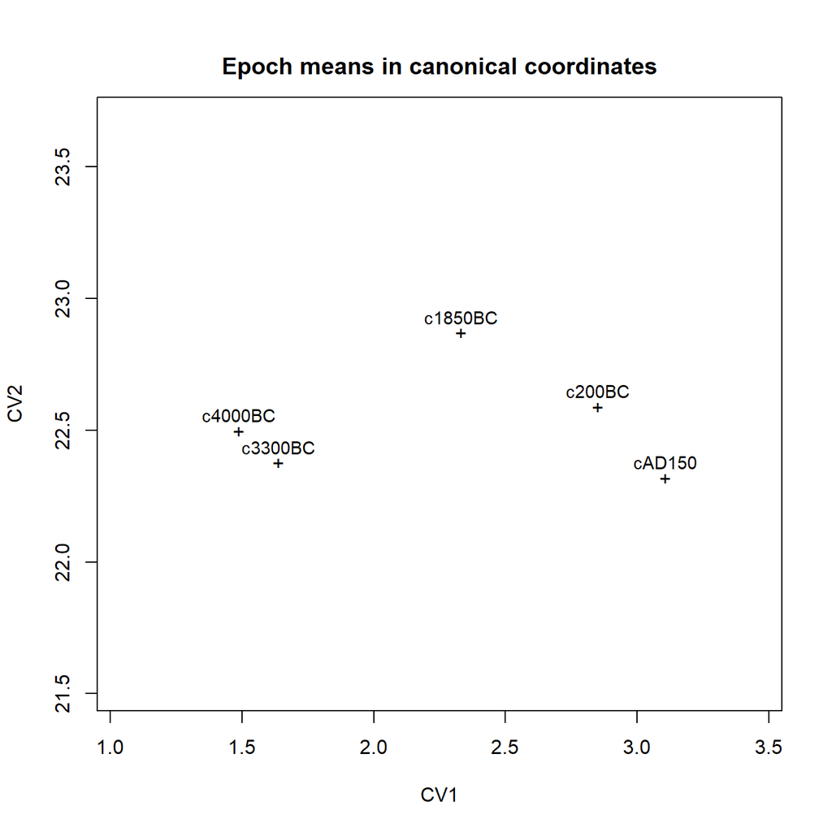

```r
> library(MASS)
> eqscplot(Y[,1:2],xlim=c(1,3.5),ylim=c(22.2,23),pch="+",lwd=4,xlab="CV1",ylab="CV2")
> title(main="Epoch means in canonical coordinates",line=1)
> text(Y[,1],Y[,2]+0.06,labels=rownames(means),cex=0.9)
```

```r
> # Radio de confianza 95%
>
> alpha <- 0.05
> R2 <- (nT-g)*p/(nT-g-p+1)*qf(1-alpha,p,nT-g-p+1)
> R <- sqrt(R2/n_i)
> round(R,2)
```

```
c4000BC c3300BC c1850BC  c200BC  cAD150
   0.58    0.58    0.58    0.58    0.58
```

Representación Canónica con círculos de confianza:

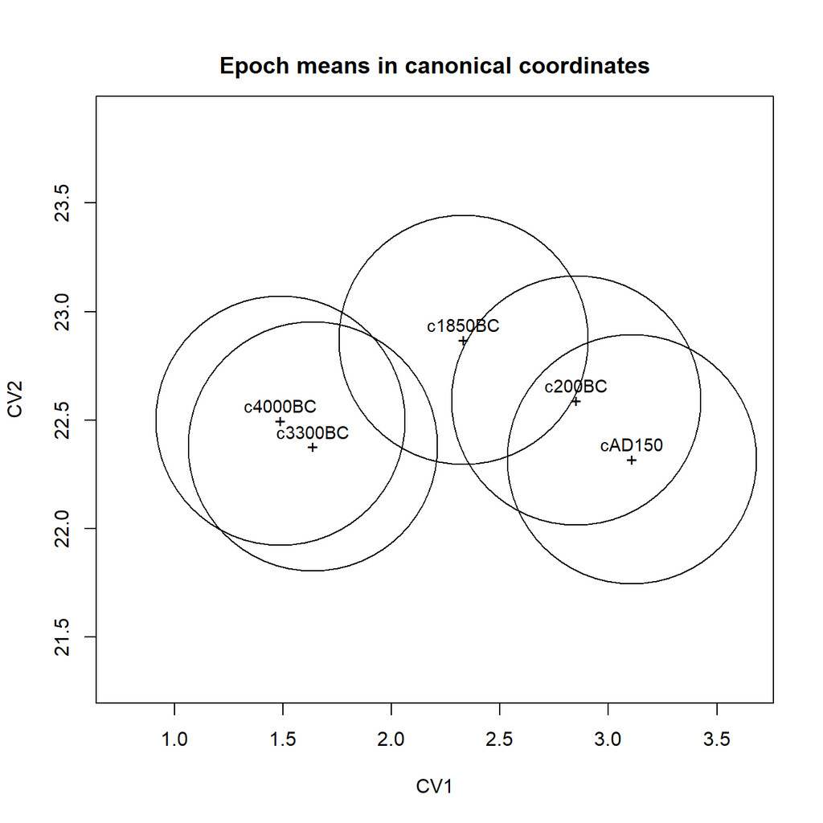

```r
> eqscplot(Y[,1:2],pch="+",lwd=4,xlim=c(0.7,3.7),xlab="CV1",ylab="CV2")
> title(main="Epoch means in canonical coordinates",line=1)
> text(Y[,1],Y[,2]+0.07,labels=rownames(means),cex=0.9)
> symbols(Y[,1],Y[,2],circles=R,inches=FALSE,add=TRUE)
```

Nótese que en esta figura, ambos ejes están en la misma escala.

```r
> # Análisis canónico discriminante
> library(candisc)
> (skulls_can <- candisc(manova))
```

```
Canonical Discriminant Analysis for EPOCH:

     CanRsq Eigenvalue Difference  Percent Cumulative
1 0.2982926  0.4250954     0.3861 88.22718     88.227
2 0.0375351  0.0389989     0.3861  8.09410     96.321
3 0.0154616  0.0157045     0.3861  3.25941     99.581
4 0.0020163  0.0020203     0.3861  0.41932    100.000

Test of H0: The canonical correlations in the
current row and all that follow are zero

  LR test stat approx F numDF  denDF  Pr(> F)
1      0.66359   3.9009    16 434.45 7.01e-07 ***
2      0.94567   0.8982     9 348.18   0.5270
3      0.98255   0.6364     4 288.00   0.6369
4      0.99798   0.2930     1 145.00   0.5892
---
Signif. codes:  0 '***' 0.001 '**' 0.01 '*' 0.05 '.' 0.1 ' ' 1
```

El primer eje canónico presenta un p valor significativo.

El gráfico es idéntico al obtenido anteriormente, pero el primer eje está cambiado de signo.

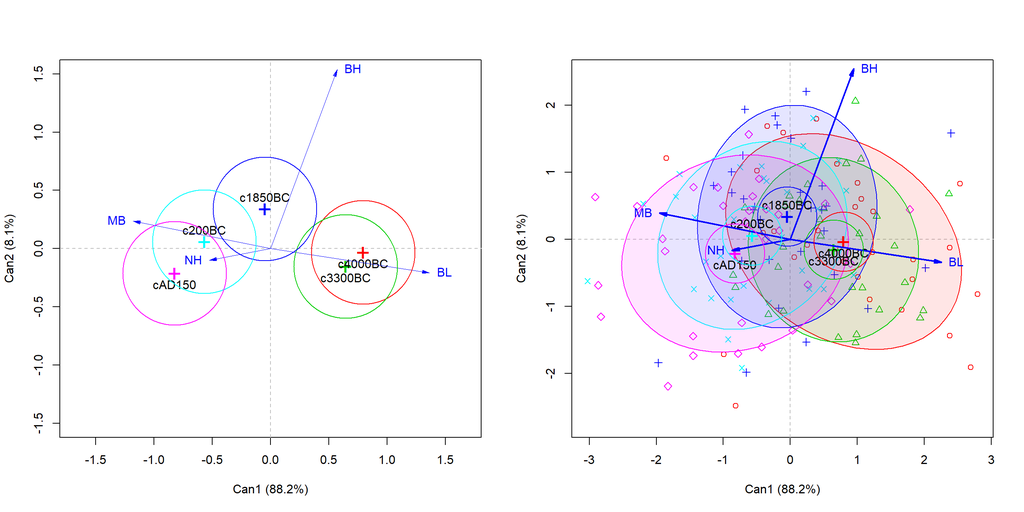

```r
> par(mfrow=c(1,2))
> plot(skulls_can, type="n", var.lwd=0, xlim=c(-1.5,1.5), ylim=c(-1.5,1.5))
> plot(skulls_can, ellipse = T, var.lwd = 2)
```

Del análisis canónico de poblaciones sobre las medias de las cinco poblaciones, usando la matriz de covarianzas común, resulta una representación significativa sobre un solo eje canónico que representa la evolución en las medidas craneales de las muestras.

Esta escala es colineal con el paso del tiempo, puesto que las medias se ordenan cronológicamente. Los círculos de confianza al 95 % muestran como, si bien estas poblaciones se solapan entre ellas, las más alejadas en el tiempo se hallan bien separadas mostrando diferencias significativas. El primer eje se explica principalmente por la variable MB, y NH en menor medida, en un sentido y BL en el otro. El segundo eje está muy relacionado con la variable BH.

3. Calcular las distancias de Malahanobis entre cada pareja de épocas.

Para ello, considerar la matriz de covarianzas común

$$\hat S= \frac{29\hat S_1+29\hat S_2+29\hat S_3+29\hat S_4+29\hat S_5}{145}$$

donde $\hat S_1, \dots, \hat S_5$ son las matrices de covarianzas en cada época.

```r
> D_M <- function(X,S){
+   S.inv <- solve(S)
+   n <- nrow(X)
+   D <- matrix(0,nrow=n,ncol=n)
+   for(i in 1:(n-1)) for(j in (i+1):n) D[i,j] <- t(X[i,]-X[j,]) %*% S.inv %*% (X[i,]-X[j,])
+   D <- D + diag(0,n) + t(D)
+   rownames(D) <- colnames(D) <- rownames(X)
+   D
+ }
>
> Malah <- D_M(means, S)
> round(Malah, 3)
```

```
        c4000BC c3300BC c1850BC c200BC cAD150
c4000BC   0.000   0.091   0.903  1.881  2.697
c3300BC   0.091   0.000   0.729  1.594  2.176
c1850BC   0.903   0.729   0.000  0.443  0.911
c200BC    1.881   1.594   0.443  0.000  0.219
cAD150    2.697   2.176   0.911  0.219  0.000
```

4. Realizar un escalado multidimensional con la matriz de distancias obtenida en el apartado anterior y representar las cinco épocas con las dos coordenadas principales.

```r
> # Escalado MD de Dist. de Malahanobis
>
> mds <- cmdscale(as.dist(sqrt(Malah)), eig=T)
> mds
```

```
$points
               [,1]        [,2]
c4000BC -0.79515585  0.03311963
c3300BC -0.64549355  0.15347046
c1850BC  0.04762133 -0.33983601
c200BC   0.56774779 -0.05868023
cAD150   0.82528029  0.21192615

$eig
[1] 2.054628e+00 1.884947e-01 7.590489e-02 9.765007e-03 3.167755e-17

$x
NULL

$ac
[1] 0

$GOF
[1] 0.9632127 0.9632127
```

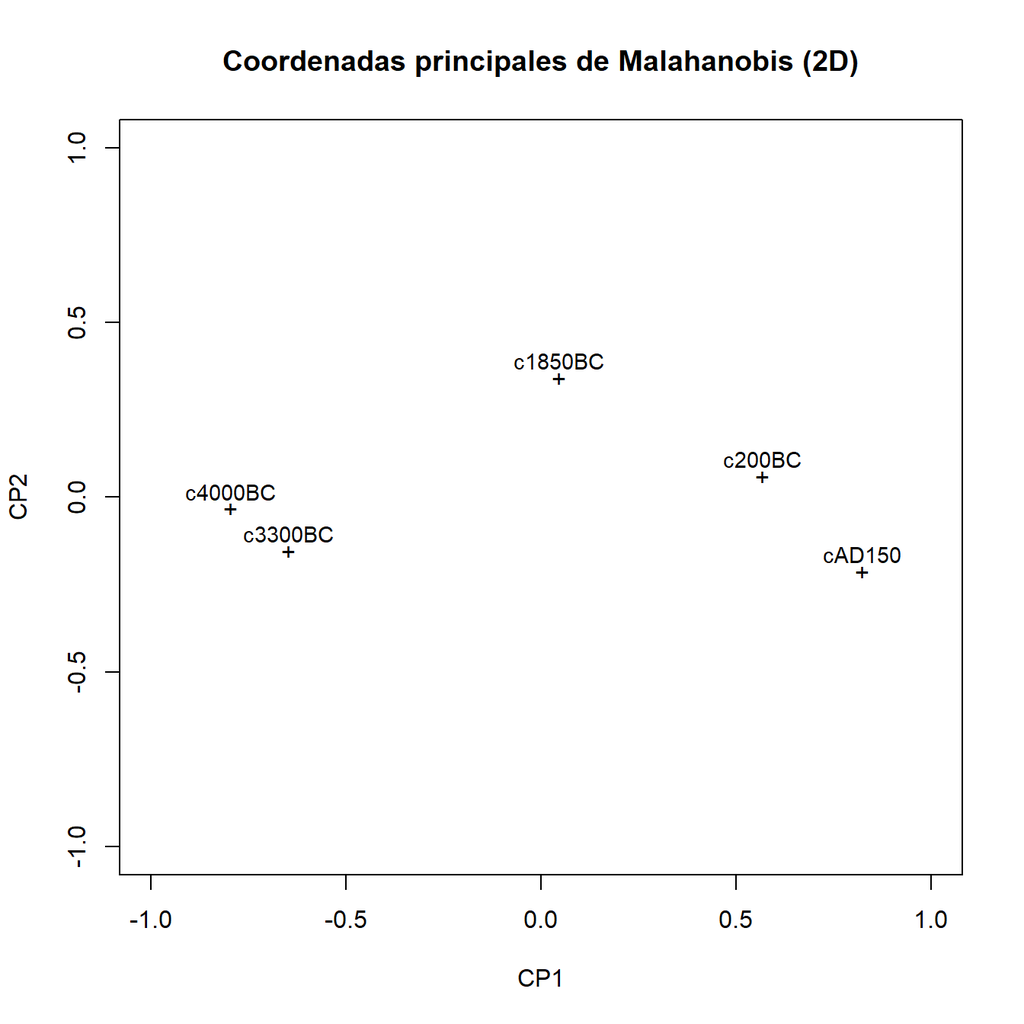

```r
> plot(mds$points[,1], -mds$points[,2], pch="+", xlab="CP1", ylab="CP2",
+      xlim=c(-1,1), ylim=c(-1,1), main = "Coordenadas principales de Malahanobis (2D)")
> text(mds$points[,1], -mds$points[,2]+0.05, labels=rownames(means), cex=0.9)
```

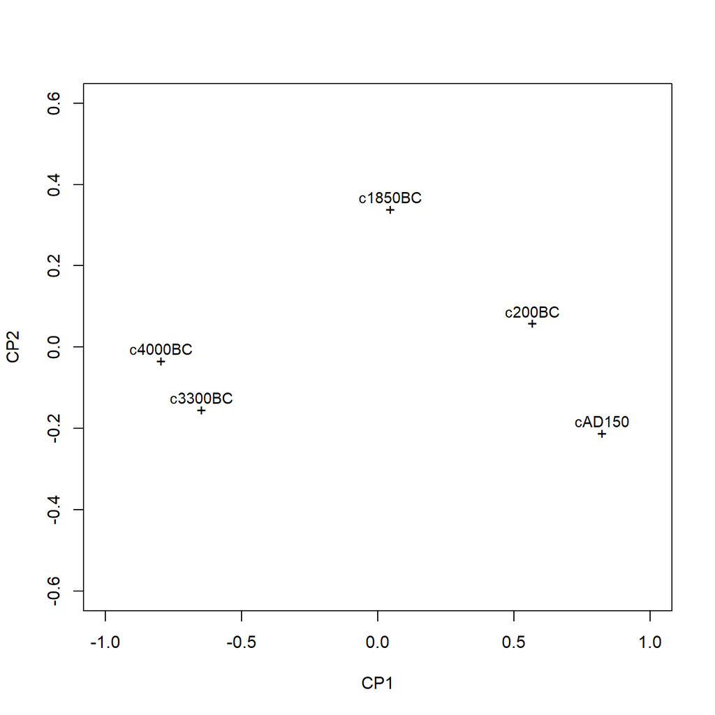

```r
> Z <- (X %*% V2)[,1:2]
> plot(Z, pch="+",xlim=c(-1,1),ylim=c(-0.6,0.6),xlab="CP1",ylab="CP2")
> text(Z[,1],Z[,2]+0.03,labels=rownames(means),cex=0.9)
```

Se ha mostrado cómo la distancia de Mahalanobis entre cada par de poblaciones (i, j) coincide con la distancia euclídea (la que se observa sobre el gráfico) entre las filas (i, j) de la matriz de coordenadas canónicas. Esto se justifica por el uso de la métrica de la matriz de covarianzas común, en ambos casos.

# Ejercicio 8: MDS en Ecología

Escalado multidimensional no métrico en Ecología

El escalado multidimensional no métrico puede realizarse usando la función `isoMDS()` del paquete `MASS`. Esta función necesita como entrada las disimilaridades entre observaciones (sites). La función `vegdist()` del paquete `vegan` contiene algunas disimilaridades apropiadas en ecología de comunidades (donde pueden haber muchos ceros). El valor por defecto es la disimilaridad de Bray-Curtis, también conocida como como disimilaridad de Steinhaus, o en Finlandia como índice de Sørensen.

```r
> # generación de datos
> coenocline <- function(x,A0,m,r,a,g, int=T, noise=T) {
+ #x is the environmental range
+ #A0 is the maximum abundance of the species at the optimum environmental conditions
+ #m is the value of the environmental gradient that represents the optimum conditions
+ #for the species
+ #r the species range over the environmental gradient (niche width)
+ #a and g are shape parameters representing the skewness and kurtosis
+ # when a=g, the distribution is symmetrical
+ # when a>g - negative skew (large left tail)
+ # when a<g - positive skew (large right tail)
+ #int - indicates whether the responses should be rounded to integers (=T)
+ #noise - indicates whether or not random noise should be added (reflecting random sampling)
+ #NOTE.  negative numbers converted to 0
+         b <- a/(a+g)
+         d <- (b^a)*(1-b)^g
+         cc <- (A0/d)*((((x-m)/r)+b)^a)*((1-(((x-m)/r)+b))^g)
+         if (noise) {n <- A0/10; n[n<0]<-0; cc<-cc+rnorm(length(cc),0,n)}
+         cc[cc<0] <- 0
+         cc[is.na(cc)]<-0
+         if (int) cc<-round(cc,0)
+         cc
+ }
> #plot(coenocline(0:100,40,40,20,1,1, int=T, noise=T), ylim=c(0,100))
>
>
> set.seed(1)
> x <- seq(0,50,l=10)
> n <- 10
> sp1<-coenocline(x=x,A0=5,m=0,r=2,a=1,g=1,int=T, noise=T)
> sp2<-coenocline(x=x,A0=70,m=7,r=30,a=1,g=1,int=T, noise=T)
> sp3<-coenocline(x=x,A0=50,m=15,r=30,a=1,g=1,int=T, noise=T)
> sp4<-coenocline(x=x,A0=7,m=25,r=20,a=0.4,g=0.1,int=T, noise=T)
> sp5<-coenocline(x=x,A0=40,m=30,r=30,a=0.6,g=0.5,int=T, noise=T)
> sp6<-coenocline(x=x,A0=15,m=35,r=15,a=0.2,g=0.3,int=T, noise=T)
> sp7<-coenocline(x=x,A0=20,m=45,r=25,a=0.5,g=0.9,int=T, noise=T)
> sp8<-coenocline(x=x,A0=5,m=45,r=5,a=1,g=1,int=T, noise=T)
> sp9<-coenocline(x=x,A0=20,m=45,r=15,a=1,g=1,int=T, noise=T)
> sp10<-coenocline(x=x,A0=30,m=50,r=5,a=1,g=1,int=T, noise=T)
> X <- cbind(sp1, sp10,sp9,sp2,sp3,sp8,sp4,sp5,sp7,sp6)
> #X<-X[c(1,10,9,2,3,8,4,5,7,6),]
> colnames(X) <- paste("Sp",1:10,sep="")
> rownames(X) <- paste("Site", c(1,10,9,2,3,8,4,5,7,6), sep="")
> X <- X[c(1,4,5,7,8,10,9,6,3,2),]
> data <- data.frame(Sites=factor(rownames(X),levels=rownames(X)), X)
```

1. Calcular el NMDS isométrico en 2 dimensiones con la disimilaridad de Bray-Curtis para estos datos y representar el mapa con las posiciones de las observaciones (mejor con los nombres de las sites). ¿Cual es el stress (en porcentaje) de la representación?
2. El paquete vegan dispone de la función `metaMDS()` más flexible. Aunque el algoritmo es distinto al de la función `isoMDS()`, podemos utilizar el mismo engine, la disimilaritad de Bray, la configuración inicial `cmdscale()` y `autotransform=FALSE` para obtener un resultado parecido al del apartado anterior. Dibujar el mapa y calcular el stress. ¿Mejor que el anterior? Nota: En el mapa, si conviene, tal vez debamos cambiar el signo de algún eje.
3. Para comparar dos configuraciones o mapas, en el paquete vegan disponemos de la maravillosa función `procrustes()`. Comparar los dos mapas que tenemos con esta función y su `plot()` por defecto. Nota: El origen de las flechas son los puntos del segundo mapa. La punta de las flechas son los puntos del primer mapa. ¡Atención! Los ejes pueden rotar, cambiar de signo y encoger.
4. Finalmente vamos a calcular un NMDS con la función `metaMDS()` y el `engine = "monoMDS"`, dejando los otros parámetros por defecto. Representar el mapa y calcular el stress (multiplicado por 100 para que sea un porcentaje).

Observar que la solución es muy similar a la que se obtiene en la web con la función `ordiplot()`. Interpretar el mapa según la altura de las observaciones en la montaña